# CV

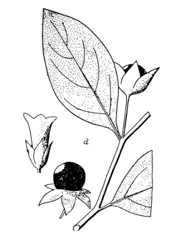

Jannigje Helena (Samira) Verhees

jh.verhees *at* gmail

## Employment

### Current

- **Research fellow** at Linguistic Convergence Laboratory at NRU HSE, Moscow | [Page](https://www.hse.ru/en/staff/samiraverhees)

  2018 - Now

### Past

- **Intern / Research assistant** at Linguistic Convergence Laboratory at NRU HSE, Moscow

  2017-2018
- **Intern / Research assistant** at Laboratory of the Languages of the Caucasus at NRU HSE, Moscow

  2016

Image: *Atropa Caucasica* (Galuško 1980: 72)

## Education

### PhD

- **Филолгия и лингвистика: теория языка / Philology and linguistics: theory of language** (2015–2019)

  NRU HSE Moscow

  Dissertation: ‘Эвиденциальность как часть видо-временной системы в нахско-дагестанских языках’ (*in Russian*) / ‘Evidentiality as part of tense-aspect in East Caucasian languages’ | [Text](https://www.hse.ru/sci/diss/300367563) and [data](https://github.com/sverhees/dissertation_evidentiality)

  Supervisor: Michael Daniel

### Master

- **Advanced studies in linguistics: linguistics in a comparative perspective** (2014–2015)

  Ghent University

  Thesis: ‘Evidentiality in the Avar-Andic languages’

  Supervisor: Leonid Kulikov
- **Taal -en regiostudies: slavistiek (richting Russisch) / Language and area studies: Slavic studies (Russian)** (2013–2014)

  KU Leuven

  Thesis: ‘“Je zult het niet geloven, maar een bril is geen ruimtepak” - Humor in spontane coversatie in het Russisch (*in Dutch*) /  
  ’“You won’t believe this, but glasses are not a space suit” - Humor in spontaneous conversation in Russian’

  Supervisor: Tatjana Soldatjenkova, Kurt Feyaerts

### Bachelor

- **Slavische talen en culturen (Russisch) / Slavic languages and cultures (Russian)** (2010–2013)

  University of Amsterdam

  Thesis: Japanse haiku poëzie in het Russisch (*in Dutch*) / Japanese haiku poetry in Russian

  Supervisor: Alla Peeters-Podgaevskaja

### Other

- **Summer School** on areal linguistics and languages of Russia (September 2018)

  NRU HSE Moscow
- **LOT Winter School** on computational and statistical methods (January 2018)

  VU Amsterdam
- **Japanstudies** (Propedeuse) (2012–2013)

  Leiden University

### References

Galuško, A.I. 1980. *Flora Severnogo Kavkaza. Opredelitel’, T. 3. [Flora of the North Caucasus. Determiner, V. 3.]*. Rostov: Izdatel’stvo Rostovskogo Universiteta.